# act_report

## Report: act_report

- The data wrangling process involves three main steps. for example, the first step is to collect the data then clean the data and the final step is the analysis stage. Data wrangling can be defined as the process of converting raw data into a format it is easier to understand. Data manipulation is a core data analysis. It can involve scraping data from the web, carrying out statistical analysis, and creating dashboards and visualizations. We can see that all this process ensures that the data are in a format we can use. The insights gained during the data wrangling can be invaluable. When the data wrangling is not done undoubtedly can affect the data modeling that can impact the organization's decision-making and reputation. For this reason, I have managed to follow all the processes needed for the data wrangling process and provided a clear report of the findings. I have also produced visualizations and incites as seen during the data wrangling process.
- As I have explained I used more than three datasets for this project as follows; image-predictions.tsv, twitter_archive, tweet_data_df.csv, and tweet_json for analysis. These data were gathered from different websites and either downloaded programmatically or manually or through the APIs. After cleaning every dataset at the individual steps, I managed to combine the three-dataset using the panda's merge function to become clean_twitter_archive.csv. clean_twitter_archive.csv become my final dataset which I later used for analysis and visualization. This dataset has 18 columns. I only used the newly created dog_stage columns for visualization. However other columns such as rating_numerator and rating_denominator were used for analysis. The purpose of my analysis was to find out the dog stage which has the highest percentage. During the practice, I managed to learn how to extract words from text using the extract panda’s function and create new columns and append them to the dataset.

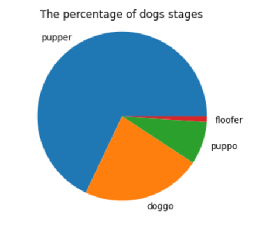

- From the visual analysis, I found out that the dog stage with the highest percentage is pepper followed by doggo. The dog stage with the minimum percentage is floofer. After visualization, I documented three insights from the data. The insights were based on the dog stages which include doggo, Puppo, floofer, and pupper. The following were my insights; pupper has the highest percentage, floofer has the lowest percentage and finally doggo has the second largest percentage.